# Analysis Plan

Boyd Nguyen

10/06/2020

# Background

This is a summary of all the statistical analyses carried out by me, using open datasets from https://openpsychologydata.metajnl.com/articles/10.5334/jopd.35/. The purpose of this paper is to replicate the findings in this study, as well as investigating other hypotheses left unanswered by the original authors.

# Analysis

## Data preparation

The following packages are loaded.

```r
library(tidyverse)
library(dplyr)
library(ggplot2)
library(psych)
library(readr)
library(forcats)
```

Then, the dataset is loaded, with columns parsed according to variable types.

```r
ppinfo <- read_csv("participant-info.csv",
                   col_types = cols(
                               intervention = col_factor(),
                               sex = col_factor(),
                               educ = col_factor(),
                               income = col_factor()
                                        ))
```

In the original dataset, categorical variables are coded as integers. For ease of understanding, I gave explicit names to the variables’ levels.

```r
levels(ppinfo$sex) <- c("Male", "Female")
levels(ppinfo$income) <- c("Above average", "Below average", "Average")
levels(ppinfo$intervention) <- c("Control", "Strengths", "3GT", "Gratitude")
levels(ppinfo$educ) <- c("Postgrad", "Below year 12", "Bachelors", "Year 12", "Vocational")
```

## Descriptives

### Descriptive statistics for all participant variables.

```r
ppinfo_descriptives <- summary(ppinfo[,2:6])
gender_age <- by(ppinfo$age, ppinfo$sex, describe)

ppinfo_descriptives
```

```
##     intervention     sex           age                   educ
##  Control  :73    Male  : 44   Min.   :18.00   Postgrad     :117
##  Strengths:72    Female:251   1st Qu.:34.00   Below year 12: 14
##  3GT      :74                 Median :44.00   Bachelors    :104
##  Gratitude:76                 Mean   :43.76   Year 12      : 21
##                               3rd Qu.:52.00   Vocational   : 39
##                               Max.   :83.00
##            income
##  Above average: 86
##  Below average: 73
##  Average      :136
##
##
##
```

```r
gender_age
```

```
## ppinfo$sex: Male
##    vars  n  mean   sd median trimmed   mad min max range skew kurtosis   se
## X1    1 44 42.98 14.1     44   42.81 17.05  18  71    53 0.02    -1.05 2.13
## ------------------------------------------------------------
## ppinfo$sex: Female
##    vars   n mean    sd median trimmed   mad min max range skew kurtosis   se
## X1    1 251 43.9 12.14     44   43.68 13.34  19  83    64  0.2    -0.44 0.77
```

There are considerably more females than males. As a result, the findings might not be representative of both sexes.

### Inspection of age distribution

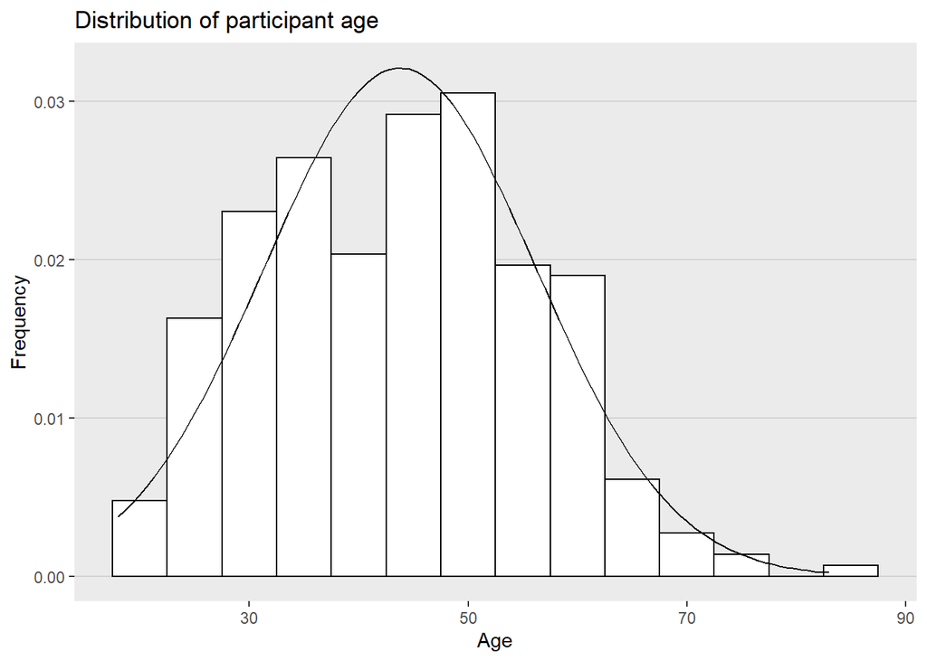

### Inspection of income distribution

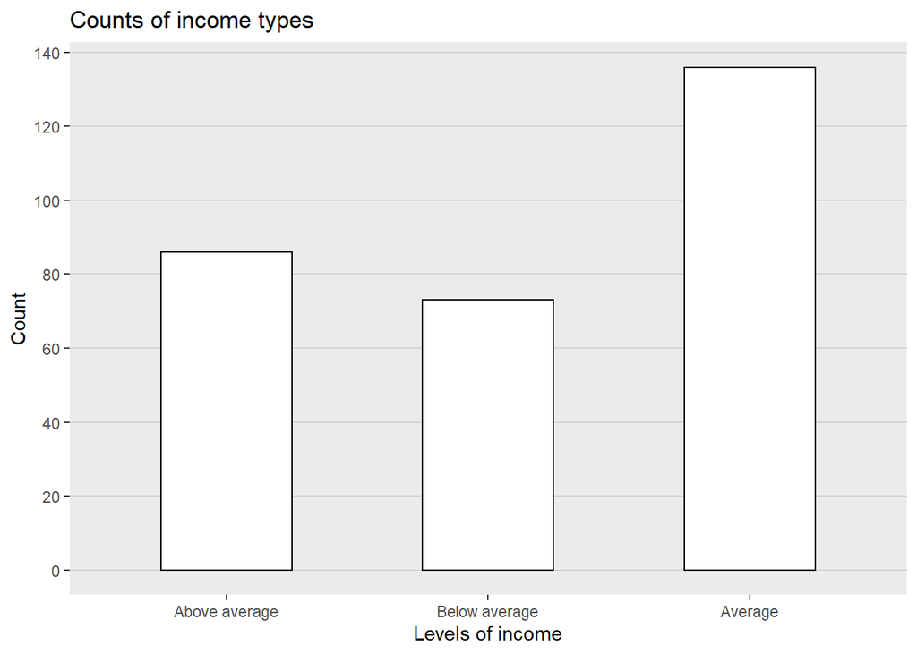

### Inspection of education distribution

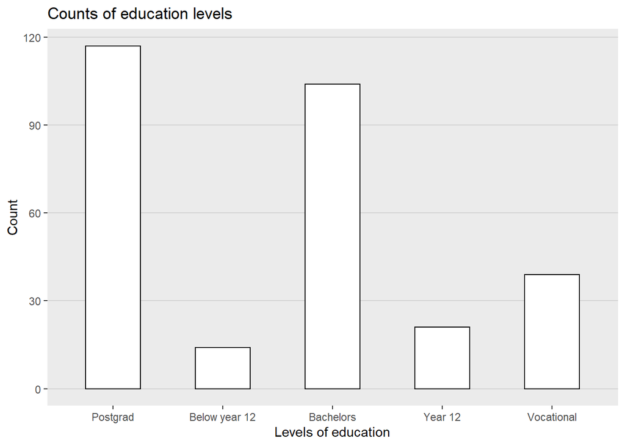

### Equal assignment checks

To check whether there are equal proportions of males and females in each intervention group, I conducted a Chi-square Goodness-of-Fit Test on the number of males and females in each intervention.

```r
sex_intervention <- table(ppinfo$intervention,ppinfo$sex)
sex_group_prop <- round(prop.table(sex_intervention, margin =2)*100)
chisq <- chisq.test(sex_intervention)

chisq
```

```
##
##  Pearson's Chi-squared test
##
## data:  sex_intervention
## X-squared = 0.47685, df = 3, p-value = 0.9239
```

Chi-square test is not significant. This means that there are equal proportions of sexes in each intervention.

To check whether there are equal proportions of income levels in each intervention group, I conducted another Chi-square Goodness-of-Fit Test. My rationale behind the test is the possibility that higher income people are less affected by the interventions.

```r
income_intervention <- table(ppinfo$intervention,ppinfo$income)
chisq2 <- chisq.test(income_intervention)

chisq2
```

```
##
##  Pearson's Chi-squared test
##
## data:  income_intervention
## X-squared = 1.7935, df = 6, p-value = 0.9377
```

Chi-square test is not significant, indicating that there are equal proportions of income levels in each intervention.

### Measurement data - number of participants completing measurement scales

```
## # A tibble: 6 x 2
##   occasion                  count
##   <fct>                     <int>
## 1 0 - Pretest                 295
## 2 1 - Posttest                147
## 3 2 - One-week follow-up      157
## 4 3 - One-month follow-up     139
## 5 4 - Three-month follow-up   134
## 6 5 - Six-month follow-up     120
```

There was a 50% drop in responses post-intervention. This calls for an investigation into who was more likely to drop out, which might affect the study’s validity.

## Drop-outs vs. Non-dropouts

To ensure there is not systematic difference between drop-outs and non-dropouts, several tests are conducted. The first one is comparing mean age between drop-outs and non drop-outs.

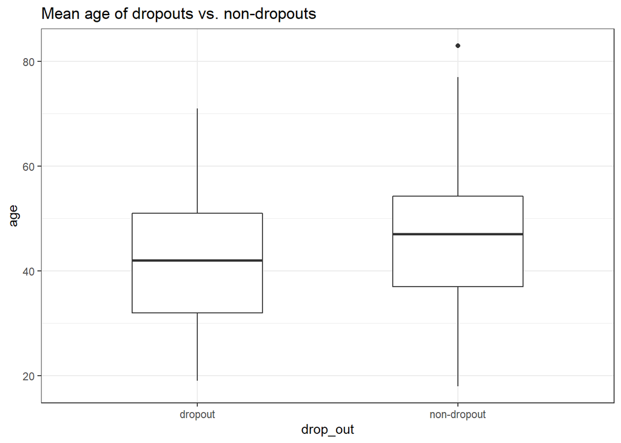

From the chart above, non-dropouts seem older than drop-outs. A t-test is needed to find out if this difference is statistically significant. But first, we need to make sure assumptions of t-test are not violated.

One assumption of t-tests is homogeneity of variance. We test this using the Levene’s test, but also see whether drop-outs and non-drop-outs have similar sample sizes.

```
## # A tibble: 2 x 2
##   drop_out    count
##   <chr>       <int>
## 1 dropout       159
## 2 non-dropout   136
```

```
## Levene's Test for Homogeneity of Variance (center = median)
##        Df F value Pr(>F)
## group   1  0.0156 0.9007
##       293
```

Since Levene’s test is not significant, and that the two groups have relatively similar sample sizes, I’ve decided a student t-test would suffice.

```
##
##  Two Sample t-test
##
## data:  age by drop_out
## t = -2.9492, df = 293, p-value = 0.003443
## alternative hypothesis: true difference in means is not equal to 0
## 95 percent confidence interval:
##  -7.045260 -1.405628
## sample estimates:
##     mean in group dropout mean in group non-dropout
##                  41.81132                  46.03676
```

I also compare initial happiness score and initial depression score between 2 groups.

```
##
##  Two Sample t-test
##
## data:  ahiTotal by drop_out
## t = -0.73665, df = 293, p-value = 0.4619
## alternative hypothesis: true difference in means is not equal to 0
## 95 percent confidence interval:
##  -4.162904  1.895331
## sample estimates:
##     mean in group dropout mean in group non-dropout
##                  69.18239                  70.31618
```

```
##
##  Two Sample t-test
##
## data:  cesdTotal by drop_out
## t = 0.12701, df = 293, p-value = 0.899
## alternative hypothesis: true difference in means is not equal to 0
## 95 percent confidence interval:
##  -2.325344  2.646191
## sample estimates:
##     mean in group dropout mean in group non-dropout
##                  15.13836                  14.97794
```